# AS3-2: 股市動態

第 21 組

2019-03-12 08:04:32

**股票動態**

股票市場是買賣雙方交易公司股票的地方，也是個人和公司投資的最受歡迎的方式之一。現在估計世界股票市場規模達到數兆。紐約證券交易所位於紐約市，是世界上最大的股票市場。 紐約證券交易所約有2,800家上市公司。在這個問題上，我們將看看其中五家公司的每月股價：IB、通用電氣（GE）、寶潔、可口可樂和波音。此問題中使用的數據來自Infochimps。

使用`read.csv()`下載並讀取以下文件：

- `data/IBMStock.csv`
- `data/GEStock.csv`
- `data/ProcterGambleStock.csv`
- `data/CocaColaStock.csv`
- `data/BoeingStock.csv`

分別存入資料框`IBM`、`GE`、`ProcterGamble`、`CocaCola`和`Boeing`， 每個資料框都有兩個變量，描述如下：

- `Date`：日期
- `StockPrice`：給定月份公司的平均股價

```r
IBM=read.csv("data/IBMStock.csv",stringsAsFactors=F)
GE=read.csv("data/GEStock.csv", stringsAsFactors=F)
ProcterGamble=read.csv("data/ProcterGambleStock.csv" , stringsAsFactors=F)
CocaCola=read.csv("data/CocaColaStock.csv",stringsAsFactors=F)
Boeing=read.csv("data/BoeingStock.csv", stringsAsFactors=F)
```

### Section-1 Summary Statistics

**§ 1.1** Our five datasets all have the same number of observations. How many observations are there in each data set?

```r
nrow(IBM)
```

```
[1] 480
```

```r
nrow(GE)
```

```
[1] 480
```

```r
nrow(ProcterGamble)
```

```
[1] 480
```

```r
nrow(CocaCola)
```

```
[1] 480
```

```r
nrow(Boeing)
```

```
[1] 480
```

```r
#480 observations in each data set
```

**§ 1.2** What is the earliest year in our datasets?

```r
#way1
head(IBM$Date)
```

```
[1] "1/1/70" "2/1/70" "3/1/70" "4/1/70" "5/1/70" "6/1/70"
```

```r
head(GE$Date)
```

```
[1] "1/1/70" "2/1/70" "3/1/70" "4/1/70" "5/1/70" "6/1/70"
```

```r
head(ProcterGamble$Date)
```

```
[1] "1/1/70" "2/1/70" "3/1/70" "4/1/70" "5/1/70" "6/1/70"
```

```r
head(CocaCola$Date)
```

```
[1] "1/1/70" "2/1/70" "3/1/70" "4/1/70" "5/1/70" "6/1/70"
```

```r
head(Boeing$Date)
```

```
[1] "1/1/70" "2/1/70" "3/1/70" "4/1/70" "5/1/70" "6/1/70"
```

```r
#way2
date<-as.Date(IBM$Date,format="%m/%d/%y")
min(date)
```

```
[1] "1970-01-01"
```

```r
#1970-01-01
```

**§ 1.3** What is the latest year in our datasets?

```r
date<-as.Date(IBM$Date,format="%m/%d/%y")
max(date)
```

```
[1] "2009-12-01"
```

```r
#2009-12-01
```

**§ 1.4** What is the mean stock price of IBM over this time period?

```r
mean(IBM$StockPrice)
```

```
[1] 144.4
```

```r
#144.4
```

**§ 1.5** What is the minimum stock price of General Electric (GE) over this time period?

```r
min(GE$StockPrice)
```

```
[1] 9.294
```

```r
#9.294
```

**§ 1.6** What is the maximum stock price of Coca-Cola over this time period?

```r
max(CocaCola$StockPrice)
```

```
[1] 146.6
```

```r
#146.6
```

**§ 1.7** What is the median stock price of Boeing over this time period?

```r
median(Boeing$StockPrice)
```

```
[1] 44.88
```

```r
#44.88
```

**§ 1.8** What is the standard deviation of the stock price of Procter & Gamble over this time period?

```r
sd(ProcterGamble$StockPrice)
```

```
[1] 18.19
```

```r
#18.19
```

### Section-2 Visualizing Stock Dynamics

**§ 2.1** Around what year did Coca-Cola has its highest stock price in this time period? Around what year did Coca-Cola has its lowest stock price in this time period?

```r
IBM$Date=as.Date(IBM$Date, "%m/%d/%y")
GE$Date=as.Date(GE$Date, "%m/%d/%y")
CocaCola$Date=as.Date(CocaCola$Date, "%m/%d/%y")
ProcterGamble$Date=as.Date(ProcterGamble$Date, "%m/%d/%y")
Boeing$Date=as.Date(Boeing$Date, "%m/%d/%y")
```

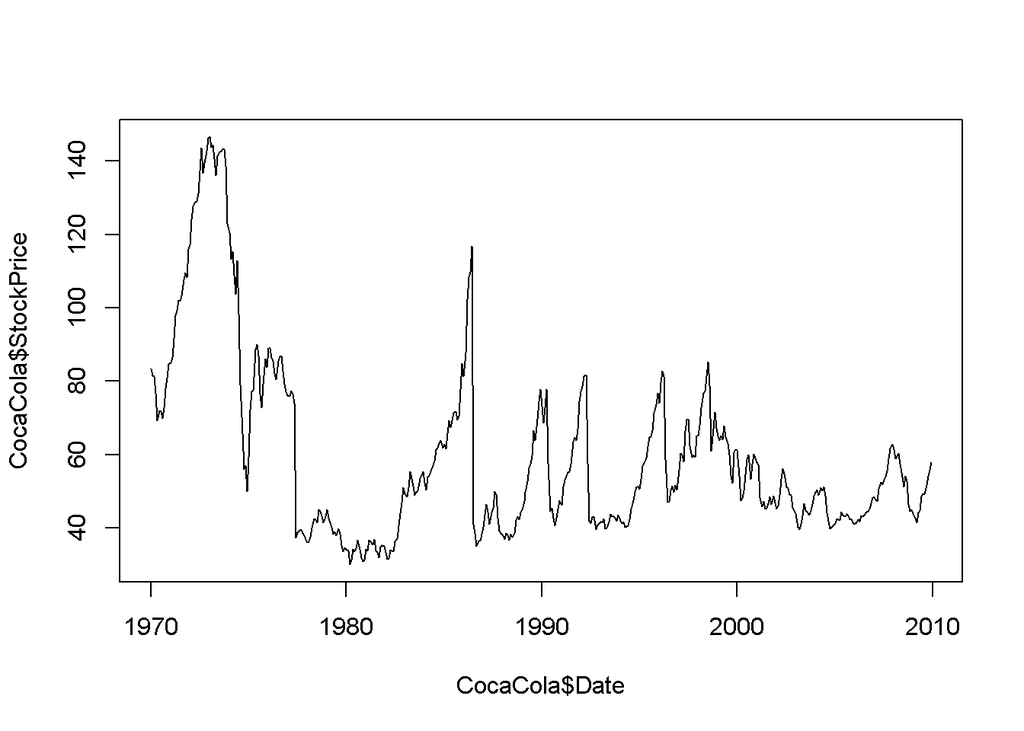

```r
plot(CocaCola$Date,CocaCola$StockPrice, type="l")
```

```r
CocaCola$Date[which.max(CocaCola$StockPrice)]
```

```
[1] "1973-01-01"
```

```r
#highest stock price in 1973
CocaCola$Date[which.min(CocaCola$StockPrice)]
```

```
[1] "1980-03-01"
```

```r
#lowest stock price in 1980
```

**§ 2.2** In March of 2000, the technology bubble burst, and a stock market crash occurred. According to this plot, which company’s stock dropped more?

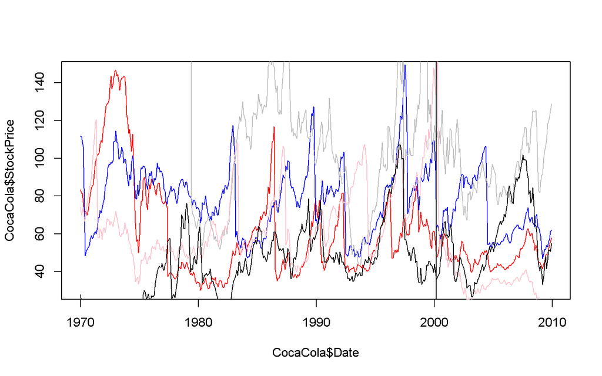

```r
plot(CocaCola$Date,CocaCola$StockPrice, type="l",col="red")
lines(ProcterGamble$Date,ProcterGamble$StockPrice,col="blue")
lines(IBM$Date,IBM$StockPrice,col="grey")
lines(GE$Date,GE$StockPrice,col="pink")
lines(Boeing$Date,Boeing$StockPrice)
abline(v=as.Date(c("2000/03/01")))
```

```r
#Procter and Gamble dropped more
```

**§ 2.3** (a) Around 1983, the stock for one of these companies (Coca-Cola or Procter and Gamble) was going up, while the other was going down. Which one was going up?

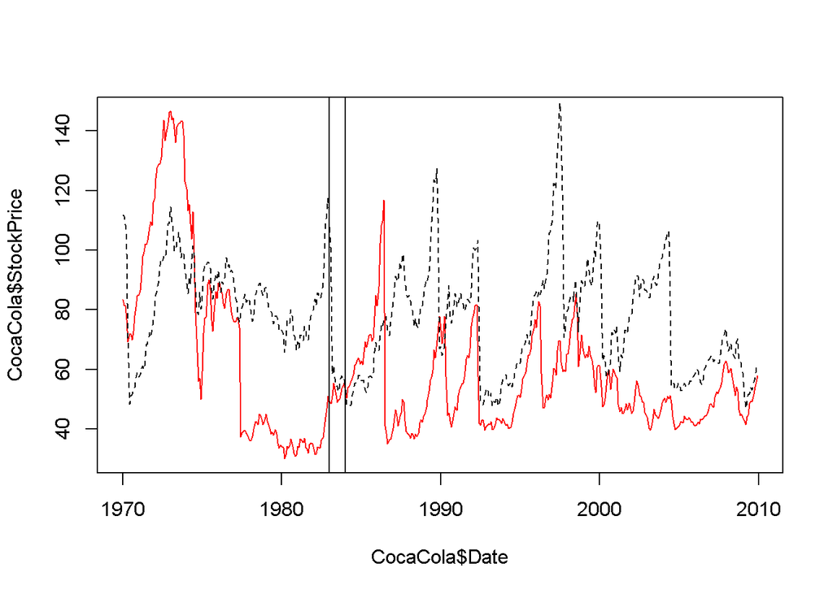

```r
plot(CocaCola$Date,CocaCola$StockPrice, type="l",col="red")
lines(ProcterGamble$Date,ProcterGamble$StockPrice,lty=2)
abline(v=as.Date(c("1983/1/1")))
abline(v=as.Date(c("1983/12/31")))
```

```r
#Coca-Cola was going up around 1983
```

2. In the time period shown in the plot, which stock generally has lower values?

```r
mean(CocaCola$StockPrice)
```

```
[1] 60.03
```

```r
mean(ProcterGamble$StockPrice)
```

```
[1] 77.7
```

```r
#Coca-Cola
```